# Pokemon dual types

Juan De Dios Santos, @jdiossantos

### This is a work in progress.

## Introduction

In the world of Pok?mon there are 18 types that are properties of the Pok?mon and their moves. A Pok?mon may have one or two types (dual-type), meaning that there are 324 posible combinations, 18 single-type Pok?mon and 306 dual-types Pok?mon. However in the games, there are no differences between the order of the types in a dual-type Pok?mon, in other words, a Flying/Dragon Pok?mon is treated in the same way a Dragon/Flying Pok?mon is treated.

In this work we will take a look at dual-type Pok?mon. Unlike the games, we will consider the order of the types of a dual-type Pok?mon using the way it is documented in the Pokedex. For example, we will treat a Flying/Dragon Pok?mon such as Noivern and Dragon/Flying Pok?mon like Altaria as having two different types.

The Pok?mon included in this study are the ones currently available in the National Pokedex, starting with Bulbasaur and ending with Zygarde; a total of 718 Pok?mon. Also, Mega Pok?mon and alternate forms of Pok?mon like Rotom forms, Therian forms are not included.

## Codebook

Our original dataset consists of two columns called `dataset.Type.1` and `dataset.Type.2`. The first column, `dataset.Type.1` has the primary type of the Pok?mon and the second one, `dataset.Type.2`, the secondary type. If the Pok?mon does not have a secondary type, the corresponding entry in `dataset.Type.2` is `<NA>` (not applicable). The dataset has a total of 718 observations (rows) because we are working with the National Pokedex and you may have noticed, the name of the Pok?mon is not included, the reason behind this is that it is not really needed since we are just interested in the types. Instead, we use the index or the number of the row. For example, row number 4 is a pure Fire type Pok?mon (Charmander).

```
##   dataset.Type.1 dataset.Type.2
## 1          Grass         Poison
## 2          Grass         Poison
## 3          Grass         Poison
## 4           Fire           <NA>
## 5           Fire           <NA>
## 6           Fire         Flying
```

## Overview

The following matrix shows the total of dual-types Pok?mon per each primary type. Each row represents a primary type and the columns the secondary type. An example on how to read it, there are 2 Bug/Electric Pok?mon, 1 Bug/Fighting, 2 Bug/Fire and so on. The -1 entries means that it does not apply, since for example a Bug/Bug Pok?mon would be a pure Bug type, and pure types are out of the score of this analysis.

```
##               dataset.Type.2
## dataset.Type.1 Bug Dark Dragon Electric Fairy Fighting Fire Flying Ghost
##       Bug       -1    0      0        2     0        1    2     13     1
##       Dark       0   -1      3        0     0        2    2      5     1
##       Dragon     0    0     -1        1     0        0    1      4     0
##       Electric   0    0      0       -1     1        0    0      3     1
##       Fairy      0    0      0        0    -1        0    0      2     0
##       Fighting   0    1      0        0     0       -1    0      1     0
##       Fire       0    0      0        0     0        6   -1      5     0
##       Flying     0    0      2        0     0        0    0     -1     0
##       Ghost      0    1      1        0     0        0    3      2    -1
##       Grass      0    3      0        0     2        3    0      4     0
##       Ground     0    3      2        1     0        0    0      3     2
##       Ice        0    0      0        0     0        0    0      2     1
##       Normal     0    0      0        0     4        0    0     23     0
##       Poison     1    3      1        0     0        2    0      3     0
##       Psychic    0    0      0        0     5        1    1      6     0
##       Rock       2    1      2        0     1        1    0      3     0
##       Steel      0    0      1        0     2        1    0      1     3
##       Water      0    4      2        2     2        2    0      7     2
##               dataset.Type.2
## dataset.Type.1 Grass Ground Ice Normal Poison Psychic Rock Steel Water
##       Bug          6      1   0      0     11       0    3     5     1
##       Dark         0      0   2      0      0       2    0     2     0
##       Dragon       0      4   1      0      0       2    0     0     0
##       Electric     0      0   0      2      0       0    0     3     0
##       Fairy        0      0   0      0      0       0    0     0     0
##       Fighting     0      0   0      0      0       2    0     1     0
##       Fire         0      2   0      2      0       1    1     1     0
##       Flying       0      0   0      0      0       0    0     0     0
##       Ghost        4      0   0      0      3       0    0     0     0
##       Grass       -1      1   2      0     14       2    0     2     0
##       Ground       0     -1   0      0      0       2    3     1     0
##       Ice          0      3  -1      0      0       2    0     0     3
##       Normal       2      1   0     -1      0       2    0     0     1
##       Poison       0      2   0      0     -1       0    0     0     1
##       Psychic      1      0   0      0      0      -1    0     0     0
##       Rock         2      6   2      0      0       2   -1     3     6
##       Steel        0      1   0      0      0       6    3    -1     0
##       Water        3      9   3      0      3       4    4     1    -1
```

The next figure, a heat map, shows the same information from the previous table in another way. The Y axis is the primary type and the X axis the secondary one. Regardings the colors, the darker they are, the smaller the frequency is and the lighest the color is, higher the frequency is.

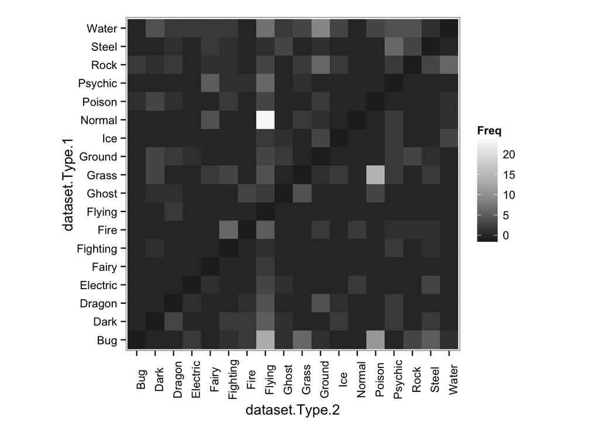

## Frequent secondary type by primary type

The figures in the section shows the quantity of secondary types by primary type. For example the first plot can be interpreted as this, “there are 13 Bug/Flying Pokemon, 11 Bug/Poison and so on.”

### Bug dual types

```
##  dataset.Type.1 dataset.Type.2 Freq
##             Bug         Flying   13
##             Bug         Poison   11
##             Bug          Grass    6
##             Bug          Steel    5
##             Bug           Rock    3
##             Bug       Electric    2
##             Bug           Fire    2
##             Bug       Fighting    1
##             Bug          Ghost    1
##             Bug         Ground    1
##             Bug          Water    1
##             Bug           Dark    0
##             Bug         Dragon    0
##             Bug          Fairy    0
##             Bug            Ice    0
##             Bug         Normal    0
##             Bug        Psychic    0
```

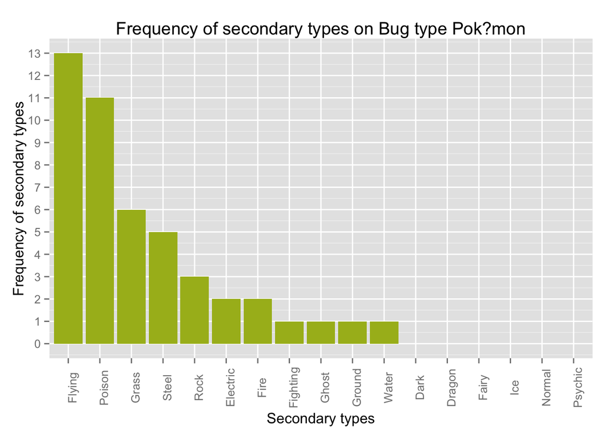

### Dark dual types

```
##  dataset.Type.1 dataset.Type.2 Freq
##            Dark         Flying    5
##            Dark         Dragon    3
##            Dark       Fighting    2
##            Dark           Fire    2
##            Dark            Ice    2
##            Dark        Psychic    2
##            Dark          Steel    2
##            Dark          Ghost    1
##            Dark            Bug    0
##            Dark       Electric    0
##            Dark          Fairy    0
##            Dark          Grass    0
##            Dark         Ground    0
##            Dark         Normal    0
##            Dark         Poison    0
##            Dark           Rock    0
##            Dark          Water    0
```

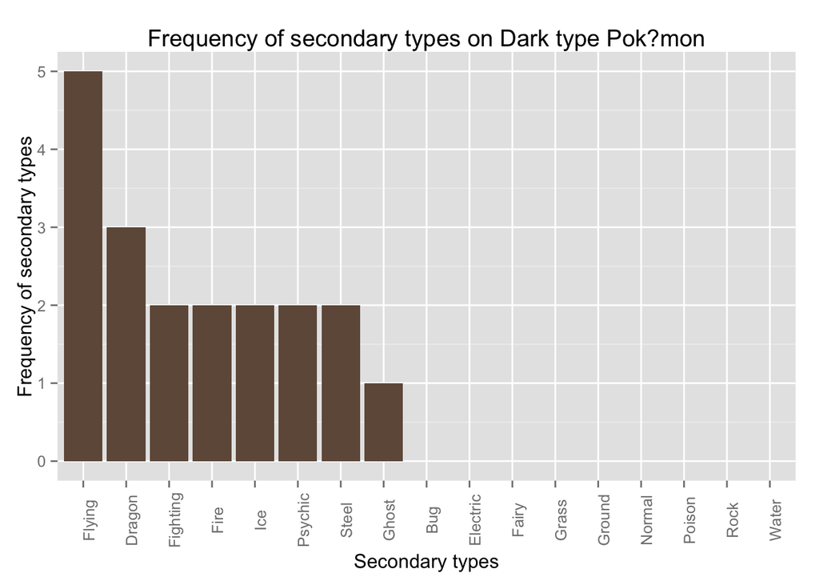

### Dragon dual types

```
##  dataset.Type.1 dataset.Type.2 Freq
##          Dragon         Flying    4
##          Dragon         Ground    4
##          Dragon        Psychic    2
##          Dragon       Electric    1
##          Dragon           Fire    1
##          Dragon            Ice    1
##          Dragon            Bug    0
##          Dragon           Dark    0
##          Dragon          Fairy    0
##          Dragon       Fighting    0
##          Dragon          Ghost    0
##          Dragon          Grass    0
##          Dragon         Normal    0
##          Dragon         Poison    0
##          Dragon           Rock    0
##          Dragon          Steel    0
##          Dragon          Water    0
```

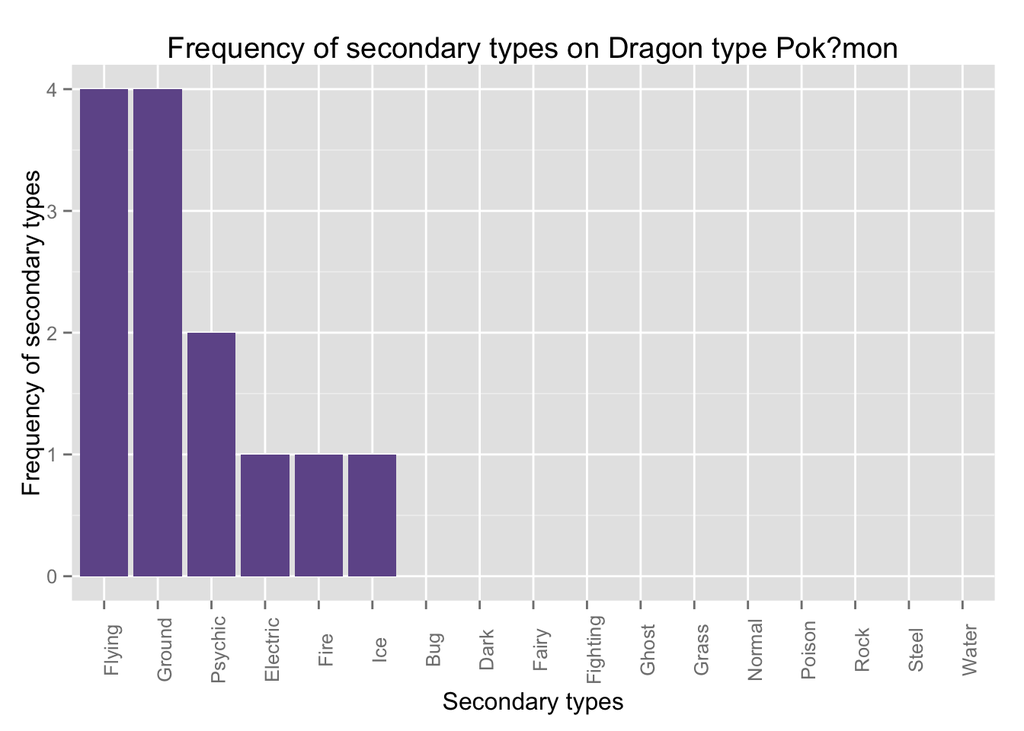

### Electric dual type

```
##  dataset.Type.1 dataset.Type.2 Freq
##        Electric         Flying    3
##        Electric          Steel    3
##        Electric         Normal    2
##        Electric          Fairy    1
##        Electric          Ghost    1
##        Electric            Bug    0
##        Electric           Dark    0
##        Electric         Dragon    0
##        Electric       Fighting    0
##        Electric           Fire    0
##        Electric          Grass    0
##        Electric         Ground    0
##        Electric            Ice    0
##        Electric         Poison    0
##        Electric        Psychic    0
##        Electric           Rock    0
##        Electric          Water    0
```

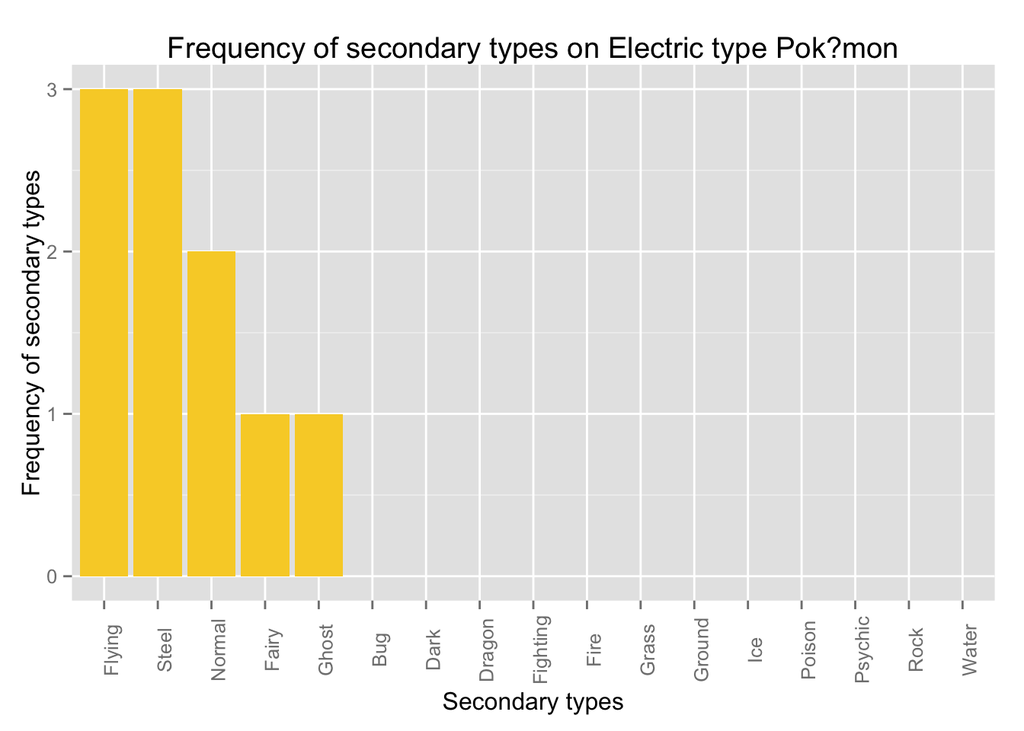

### Fairy dual type

```
##  dataset.Type.1 dataset.Type.2 Freq
##           Fairy         Flying    2
##           Fairy            Bug    0
##           Fairy           Dark    0
##           Fairy         Dragon    0
##           Fairy       Electric    0
##           Fairy       Fighting    0
##           Fairy           Fire    0
##           Fairy          Ghost    0
##           Fairy          Grass    0
##           Fairy         Ground    0
##           Fairy            Ice    0
##           Fairy         Normal    0
##           Fairy         Poison    0
##           Fairy        Psychic    0
##           Fairy           Rock    0
##           Fairy          Steel    0
##           Fairy          Water    0
```

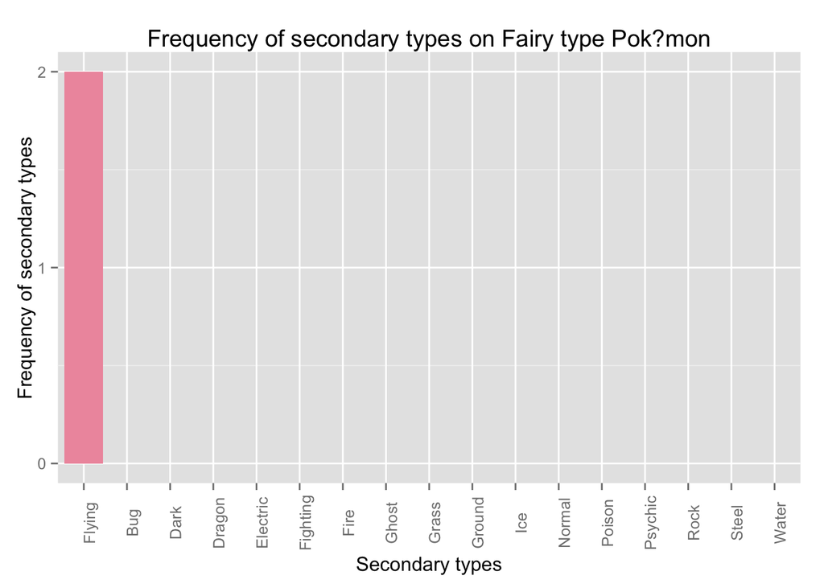

### Fighting dual type

```
##  dataset.Type.1 dataset.Type.2 Freq
##        Fighting        Psychic    2
##        Fighting           Dark    1
##        Fighting         Flying    1
##        Fighting          Steel    1
##        Fighting            Bug    0
##        Fighting         Dragon    0
##        Fighting       Electric    0
##        Fighting          Fairy    0
##        Fighting           Fire    0
##        Fighting          Ghost    0
##        Fighting          Grass    0
##        Fighting         Ground    0
##        Fighting            Ice    0
##        Fighting         Normal    0
##        Fighting         Poison    0
##        Fighting           Rock    0
##        Fighting          Water    0
```

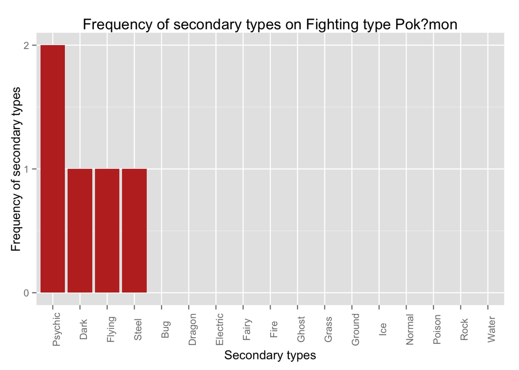

### Fire dual type

```
##  dataset.Type.1 dataset.Type.2 Freq
##            Fire       Fighting    6
##            Fire         Flying    5
##            Fire         Ground    2
##            Fire         Normal    2
##            Fire        Psychic    1
##            Fire           Rock    1
##            Fire          Steel    1
##            Fire            Bug    0
##            Fire           Dark    0
##            Fire         Dragon    0
##            Fire       Electric    0
##            Fire          Fairy    0
##            Fire          Ghost    0
##            Fire          Grass    0
##            Fire            Ice    0
##            Fire         Poison    0
##            Fire          Water    0
```

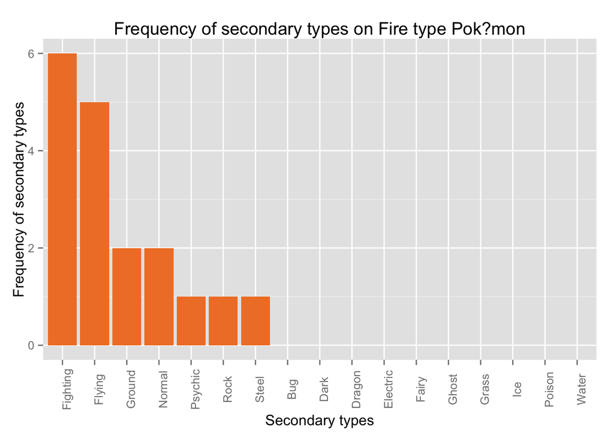

### Flying dual types

```
##  dataset.Type.1 dataset.Type.2 Freq
##          Flying         Dragon    2
##          Flying            Bug    0
##          Flying           Dark    0
##          Flying       Electric    0
##          Flying          Fairy    0
##          Flying       Fighting    0
##          Flying           Fire    0
##          Flying          Ghost    0
##          Flying          Grass    0
##          Flying         Ground    0
##          Flying            Ice    0
##          Flying         Normal    0
##          Flying         Poison    0
##          Flying        Psychic    0
##          Flying           Rock    0
##          Flying          Steel    0
##          Flying          Water    0
```

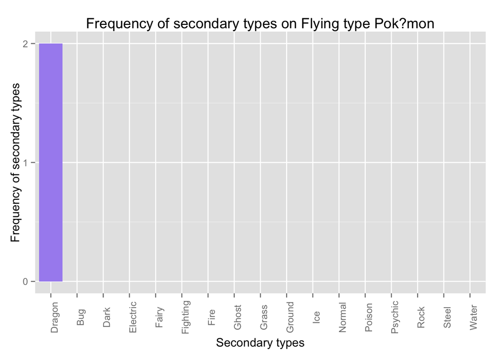

### Ghost dual types

```
##  dataset.Type.1 dataset.Type.2 Freq
##           Ghost          Grass    4
##           Ghost           Fire    3
##           Ghost         Poison    3
##           Ghost         Flying    2
##           Ghost           Dark    1
##           Ghost         Dragon    1
##           Ghost            Bug    0
##           Ghost       Electric    0
##           Ghost          Fairy    0
##           Ghost       Fighting    0
##           Ghost         Ground    0
##           Ghost            Ice    0
##           Ghost         Normal    0
##           Ghost        Psychic    0
##           Ghost           Rock    0
##           Ghost          Steel    0
##           Ghost          Water    0
```

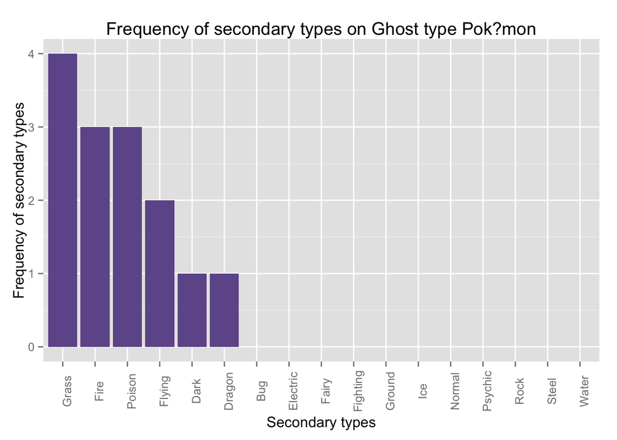

### Grass dual types

```
##  dataset.Type.1 dataset.Type.2 Freq
##           Grass         Poison   14
##           Grass         Flying    4
##           Grass           Dark    3
##           Grass       Fighting    3
##           Grass          Fairy    2
##           Grass            Ice    2
##           Grass        Psychic    2
##           Grass          Steel    2
##           Grass         Ground    1
##           Grass            Bug    0
##           Grass         Dragon    0
##           Grass       Electric    0
##           Grass           Fire    0
##           Grass          Ghost    0
##           Grass         Normal    0
##           Grass           Rock    0
##           Grass          Water    0
```

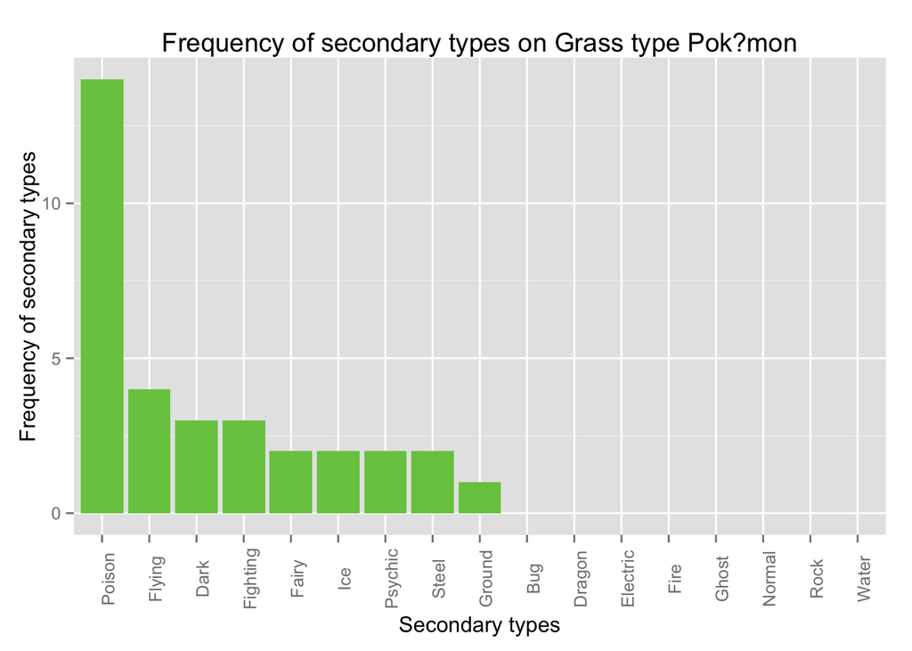

### Ground dual types

```
##  dataset.Type.1 dataset.Type.2 Freq
##          Ground           Dark    3
##          Ground         Flying    3
##          Ground           Rock    3
##          Ground         Dragon    2
##          Ground          Ghost    2
##          Ground        Psychic    2
##          Ground       Electric    1
##          Ground          Steel    1
##          Ground            Bug    0
##          Ground          Fairy    0
##          Ground       Fighting    0
##          Ground           Fire    0
##          Ground          Grass    0
##          Ground            Ice    0
##          Ground         Normal    0
##          Ground         Poison    0
##          Ground          Water    0
```

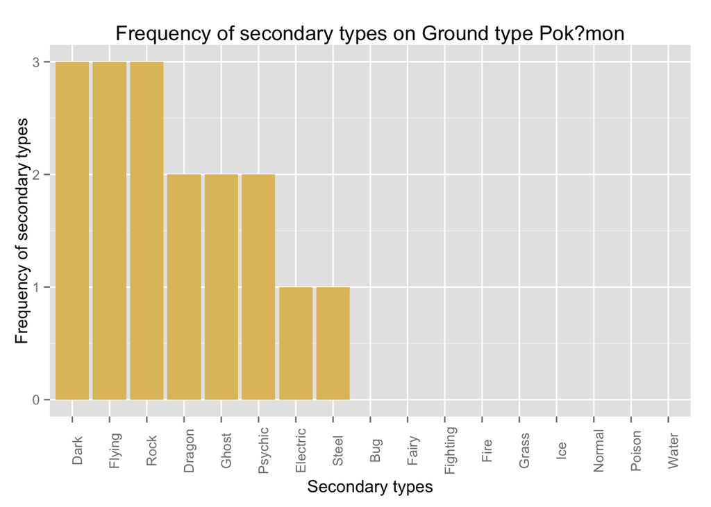

### Ice dual types

```
##  dataset.Type.1 dataset.Type.2 Freq
##             Ice         Ground    3
##             Ice          Water    3
##             Ice         Flying    2
##             Ice        Psychic    2
##             Ice          Ghost    1
##             Ice            Bug    0
##             Ice           Dark    0
##             Ice         Dragon    0
##             Ice       Electric    0
##             Ice          Fairy    0
##             Ice       Fighting    0
##             Ice           Fire    0
##             Ice          Grass    0
##             Ice         Normal    0
##             Ice         Poison    0
##             Ice           Rock    0
##             Ice          Steel    0
```

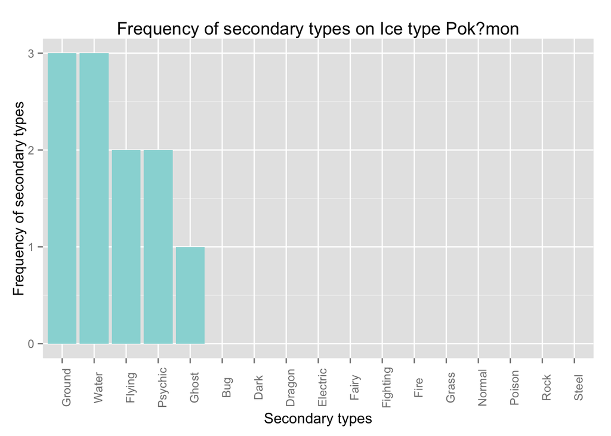

### Normal dual types

```
##  dataset.Type.1 dataset.Type.2 Freq
##          Normal         Flying   23
##          Normal          Fairy    4
##          Normal          Grass    2
##          Normal        Psychic    2
##          Normal         Ground    1
##          Normal          Water    1
##          Normal            Bug    0
##          Normal           Dark    0
##          Normal         Dragon    0
##          Normal       Electric    0
##          Normal       Fighting    0
##          Normal           Fire    0
##          Normal          Ghost    0
##          Normal            Ice    0
##          Normal         Poison    0
##          Normal           Rock    0
##          Normal          Steel    0
```

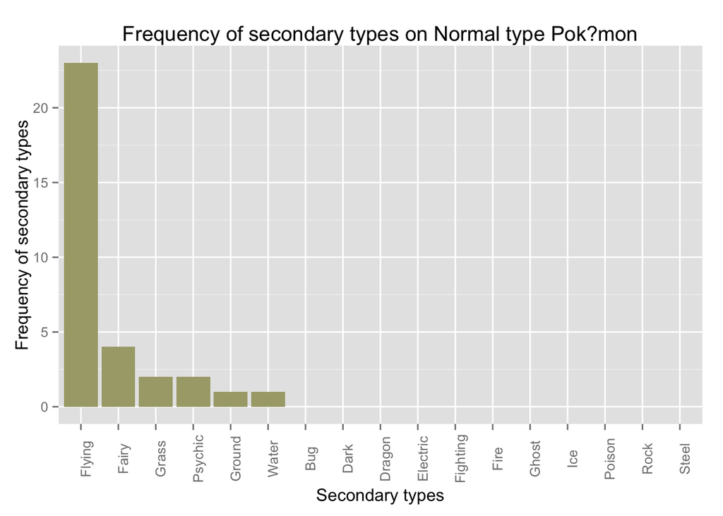

### Poison dual types

```
##  dataset.Type.1 dataset.Type.2 Freq
##          Poison           Dark    3
##          Poison         Flying    3
##          Poison       Fighting    2
##          Poison         Ground    2
##          Poison            Bug    1
##          Poison         Dragon    1
##          Poison          Water    1
##          Poison       Electric    0
##          Poison          Fairy    0
##          Poison           Fire    0
##          Poison          Ghost    0
##          Poison          Grass    0
##          Poison            Ice    0
##          Poison         Normal    0
##          Poison        Psychic    0
##          Poison           Rock    0
##          Poison          Steel    0
```

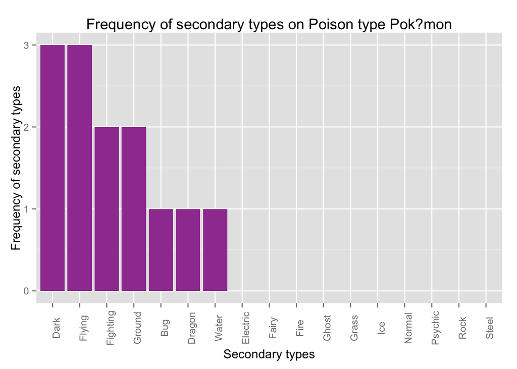

### Psychic dual type

```
##  dataset.Type.1 dataset.Type.2 Freq
##         Psychic         Flying    6
##         Psychic          Fairy    5
##         Psychic       Fighting    1
##         Psychic           Fire    1
##         Psychic          Grass    1
##         Psychic            Bug    0
##         Psychic           Dark    0
##         Psychic         Dragon    0
##         Psychic       Electric    0
##         Psychic          Ghost    0
##         Psychic         Ground    0
##         Psychic            Ice    0
##         Psychic         Normal    0
##         Psychic         Poison    0
##         Psychic           Rock    0
##         Psychic          Steel    0
##         Psychic          Water    0
```

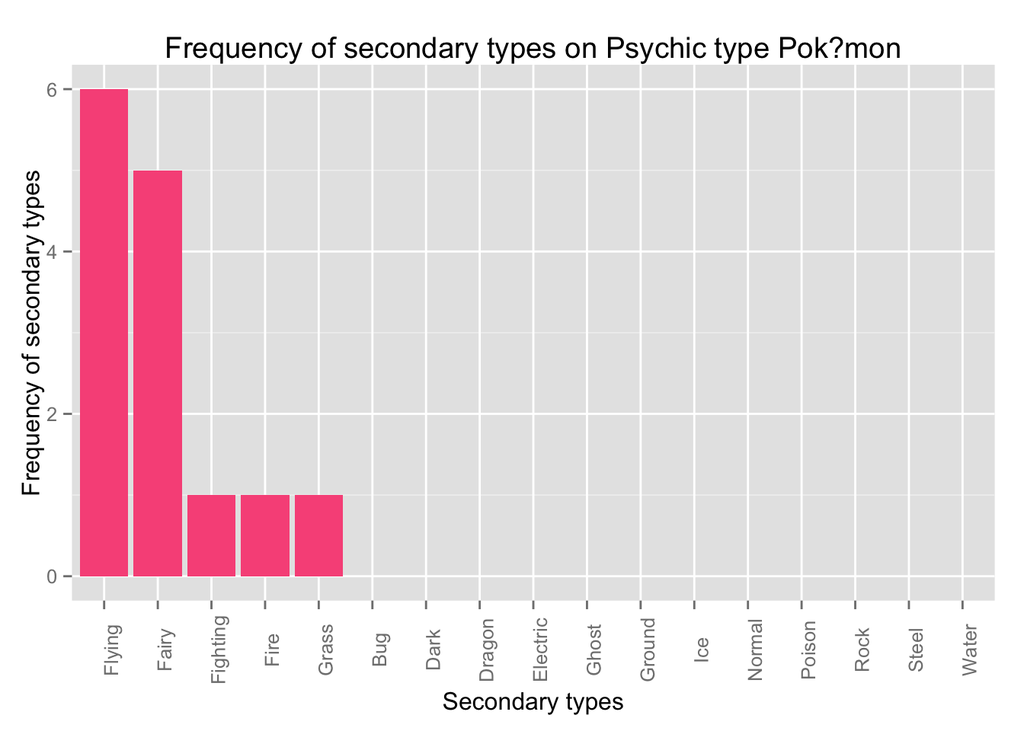

### Rock dual type

```
##  dataset.Type.1 dataset.Type.2 Freq
##            Rock         Ground    6
##            Rock          Water    6
##            Rock         Flying    3
##            Rock          Steel    3
##            Rock            Bug    2
##            Rock         Dragon    2
##            Rock          Grass    2
##            Rock            Ice    2
##            Rock        Psychic    2
##            Rock           Dark    1
##            Rock          Fairy    1
##            Rock       Fighting    1
##            Rock       Electric    0
##            Rock           Fire    0
##            Rock          Ghost    0
##            Rock         Normal    0
##            Rock         Poison    0
```

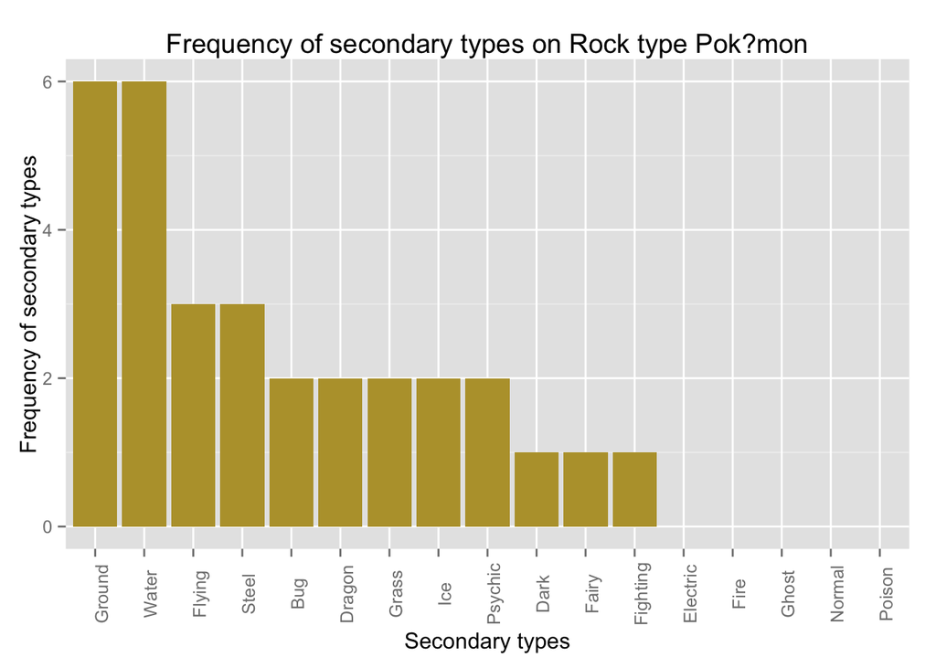

### Steel dual type

```
##  dataset.Type.1 dataset.Type.2 Freq
##           Steel        Psychic    6
##           Steel          Ghost    3
##           Steel           Rock    3
##           Steel          Fairy    2
##           Steel         Dragon    1
##           Steel       Fighting    1
##           Steel         Flying    1
##           Steel         Ground    1
##           Steel            Bug    0
##           Steel           Dark    0
##           Steel       Electric    0
##           Steel           Fire    0
##           Steel          Grass    0
##           Steel            Ice    0
##           Steel         Normal    0
##           Steel         Poison    0
##           Steel          Steel    0
##           Steel          Water    0
```

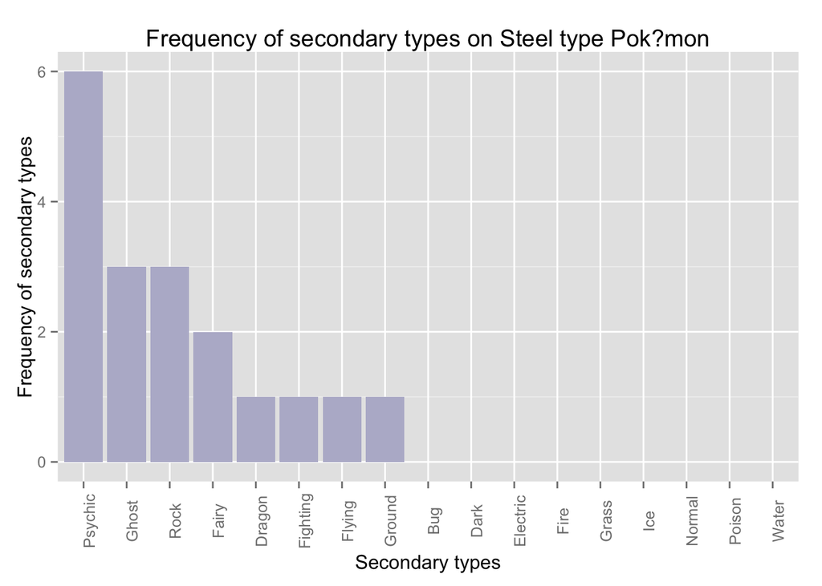

### Water dual type

```
##  dataset.Type.1 dataset.Type.2 Freq
##           Water         Ground    9
##           Water         Flying    7
##           Water           Dark    4
##           Water        Psychic    4
##           Water           Rock    4
##           Water          Grass    3
##           Water            Ice    3
##           Water         Poison    3
##           Water         Dragon    2
##           Water       Electric    2
##           Water          Fairy    2
##           Water       Fighting    2
##           Water          Ghost    2
##           Water          Steel    1
##           Water            Bug    0
##           Water           Fire    0
##           Water         Normal    0
##           Water          Water    0
```

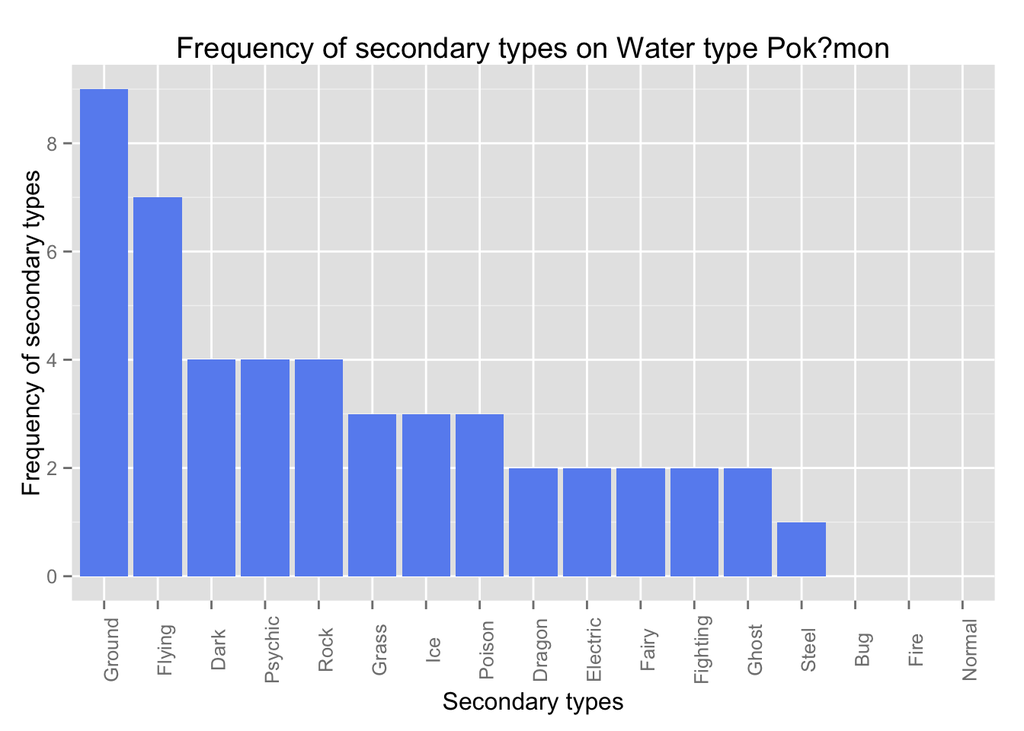

## Frequency of secondary types

This table shows the frequency of secondary types. For example, there are 3 Pok?mon with Bug as a secondary type (Anorith, Armaldo and Skorupi).

```
##      Bug     Dark   Dragon Electric    Fairy Fighting     Fire   Flying
##        3       16       14        6       17       19        9       87
##    Ghost    Grass   Ground      Ice   Normal   Poison  Psychic     Rock
##       11       18       30       10        4       31       27       14
##    Steel    Water
##       19       12
```

The most common secondary type is Flying with 87 and the rarest is Bug with just 3.

## Secondary types by region.

In this section we will summarize the dual-types per region (Kanto, Johto, Hoenn, Sinnoh, Unova and Kalos). The following tables shows the top five dual-types per region.

### Kanto region

```
##  dataset.Type.1 dataset.Type.2 region Freq
##           Grass         Poison  Kanto    9
##          Normal         Flying  Kanto    8
##             Bug         Poison  Kanto    5
##            Rock         Ground  Kanto    4
##            Rock          Water  Kanto    4
##           Water            Ice  Kanto    3
```

### Johto region

```
##  dataset.Type.1 dataset.Type.2 region Freq
##             Bug         Flying  Johto    3
##           Grass         Flying  Johto    3
##         Psychic         Flying  Johto    3
##           Water       Electric  Johto    2
##           Water          Fairy  Johto    2
##            Dark           Fire  Johto    2
```

### Hoenn region

```
##  dataset.Type.1 dataset.Type.2 region Freq
##           Water         Ground  Hoenn    4
##           Steel        Psychic  Hoenn    4
##           Grass           Dark  Hoenn    3
##           Water           Dark  Hoenn    3
##         Psychic          Fairy  Hoenn    3
##             Bug         Flying  Hoenn    3
```

### Sinnoh region

```
##  dataset.Type.1 dataset.Type.2 region Freq
##             Bug         Flying Sinnoh    4
##          Normal         Flying Sinnoh    4
##          Poison           Dark Sinnoh    3
##          Dragon         Ground Sinnoh    3
##            Rock          Steel Sinnoh    3
##            Fire       Fighting Sinnoh    2
```

### Unova region

```
##  dataset.Type.1 dataset.Type.2 region Freq
##          Normal         Flying  Unova    5
##          Ground           Dark  Unova    3
##            Dark         Dragon  Unova    3
##           Ghost           Fire  Unova    3
##         Psychic         Flying  Unova    3
##             Bug          Grass  Unova    3
```

### Kalos region

```
##  dataset.Type.1 dataset.Type.2 region Freq
##           Ghost          Grass  Kalos    4
##           Steel          Ghost  Kalos    3
##          Flying         Dragon  Kalos    2
##            Rock         Dragon  Kalos    2
##            Fire         Flying  Kalos    2
##            Rock            Ice  Kalos    2
```

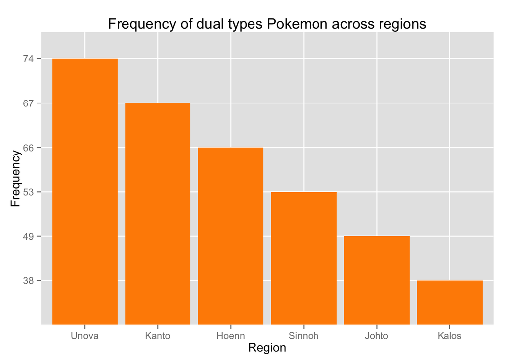

The previous figure shows that the Unova region has the most dual-type Pok?mon and Kalos has the least.

The next and last figure of this section shows the frequency of dual-type Pok?mon per each unique type splitted by generation. The x axis shows the different types, the y axis the frequency and each colored line represents a region. For example, there are 15 Bug Pok?mon with a secondary type originally from Unova.

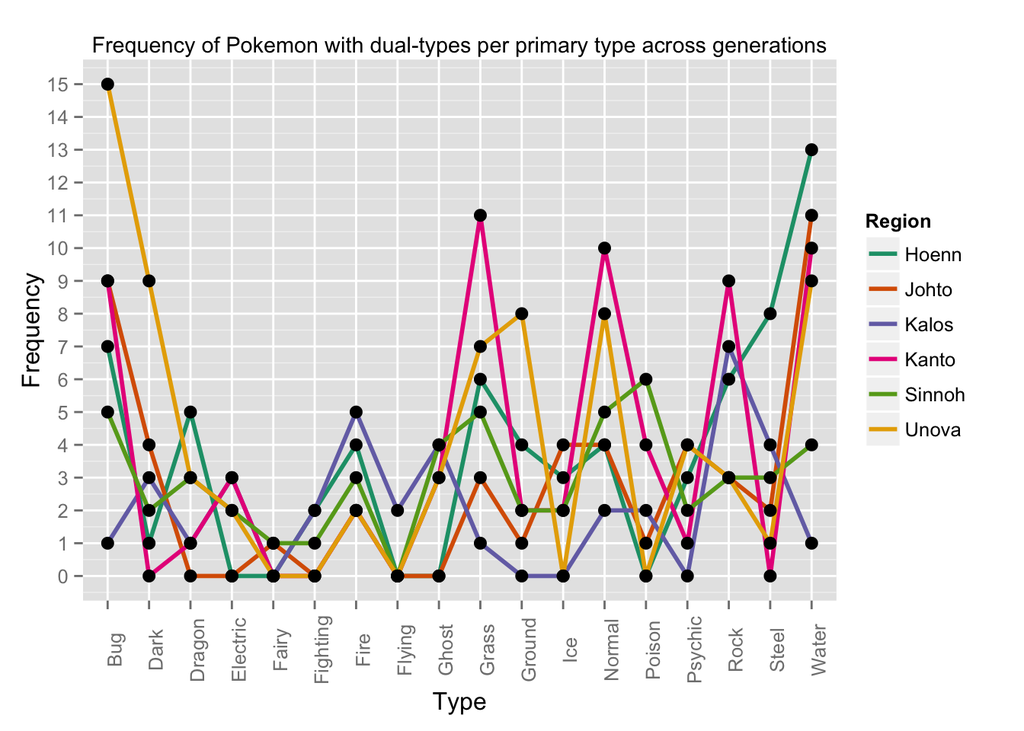

## Decision tree

This section is in some way different than the previous ones. Here we introduced a decision tree, a prediction model that uses a flow-chart structure to reach certain conclusions about a dataset based on previous observations. This simple decision tree was made to check if there is any relation between dua-types Pok?mon and their region of origin (Kanto, Johto, Hoenn, Sinnoh, Unova and Kalos). For example, are most Normal-Flying Pok?mon from the Kanto region?

What we did in this decision tree model was to split the dataset into a training set and a test set. The training set was used to teach the model about the dual-types Pok?mon and their original region and the test set for detecting how well our model can “guess” the original region of a certain dual-type Pok?mon based on what it learned.

Note that this model is not optimized at all. The purpose of doing this is just to see if there is any correlation at all.

```
##
## Classification tree:
## tree(formula = region ~ ., data = types, subset = train)
## Number of terminal nodes:  18
## Residual mean deviance:  2.249 = 409.4 / 182
## Misclassification error rate: 0.465 = 93 / 200
```

```
##          region
## tree.pred Hoenn Johto Kalos Kanto Sinnoh Unova
##    Hoenn      9     3     5     6      4     5
##    Johto      0     1     2     2      2     0
##    Kalos      4     0    10     4      3     1
##    Kanto     13     8     2    12      5     6
##    Sinnoh     1     3     2     0      4     1
##    Unova      1     6     2     2      4    14
```

If we count the correct predictions (the numbers in the diagonal) and using length of the test set (147) we get a correct prediction percentage of 34.0136054 which means that 1 out of 3 dual types Pok?mon gets a correct prediction of its region based on its dual-type. A 33% correct rate does not say much about this model; as seen from the table there is some connection in Kanto dual type Pok?mon and Unova but generally speaking my interpretation is that there is not a constant connection between a dual-type Pok?mon and its origin region.

The next figure is a representation of the tree. Each internal node represents a test on the attribute, which in this case is the primary type and the secondary type of the Pok?mon. For example, at the first internal node we have all the secondary types except for Electric, Fire, Poison and Steel. At this node we ask, is our Pok?mon secondary type any of these? If the answer if yes, we take the left route otherwise the right now. Suppose the answer to this question is no, so we take the right branch. At this new branch we ask, is our Pok?mon secondary type either Electric, Fire or Steel? If the answer is yes we take the left branch and performed another test, otherwise we take the right split and the Pok?mon is categorized as Kanto. In this exact case, the only remaining secondary type not seen in the branches is Poison, thus according to this tree, a Pok?mon that has Poison as a secondary type comes from the Kanto region. In some sense this is correct because out of all the 31 Pok?mon that has secondary Poison type, 19 comes from the Kanto region (61.3%), 3 from Johto (9.7%), 2 from Hoenn (6.5%), 2 from Sinnoh (6.5%) and 5 from Unova (16%).

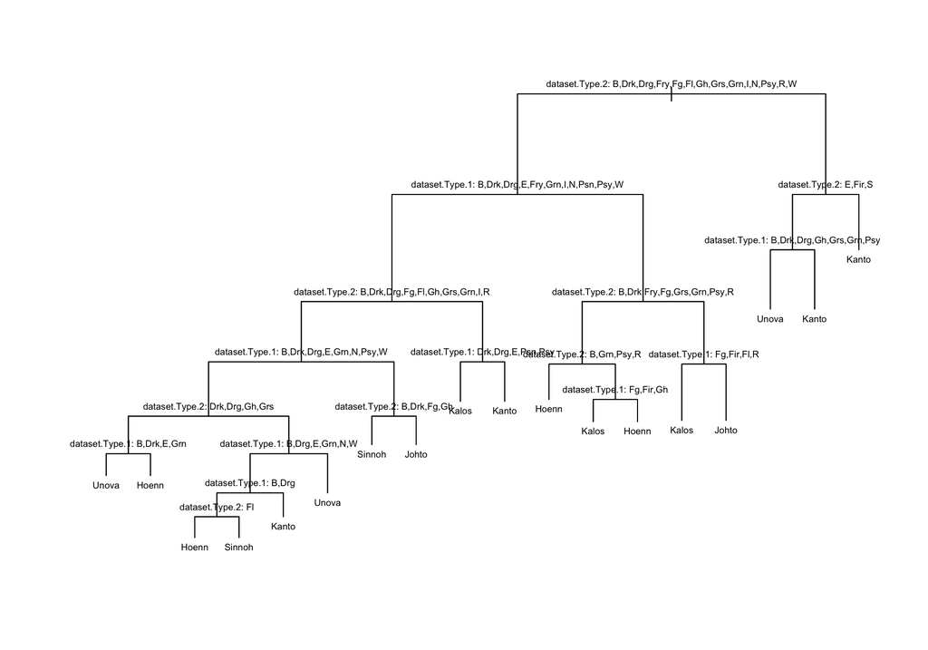

## Notes and disclaimers

- If you spot a typo, or any error in the analysis, feel free to notify me.
- This work is licensed under a [Creative Commons Attribution-NonCommercial 4.0 International License](http://creativecommons.org/licenses/by-nc/4.0/). In other words, feel free to use it, share it, edit it for non-commercial purposes and please, give credit.
- ? 2015 Pok?mon. ? 1995-2015 Nintendo/Creatures Inc./GAME FREAK inc. Pok?mon, Pok?mon character names are trademarks of Nintendo.